# CRIM 595 City of Fairfax Call Trends

Meghan Storke

15 July 2023

#STEP ONE: PACKAGES ##Packages included for my model:

```r
library(tidyverse)
library(lubridate)
library(ragg)
```

#STEP TWO: CALLS ##City of Fairfax Call Data for day, week, month, year, & type (Suspicious):

```r
# Step 1
id.calls <- "1gRoL7lZlwm7sreA5F9WbPoH5su4n4iGS"
calls.temp <- read.csv(sprintf("https://docs.google.com/uc?id=%s&export=download", id.calls))

# Step 2
calls.temp$date <- as.Date(calls.temp$date)
calls.temp$dow <- weekdays(calls.temp$date)
calls.temp$day <- day(calls.temp$date)
calls.temp$month <- substr(calls.temp$date, 6, 7)

# Step 3
calls.type <- calls.temp %>%
  group_by(type) %>%
  summarise(count = n()) %>%
  mutate(PCT = round(count/sum(count)*100,2))
calls <- subset(calls.temp, calls.temp$type == 'SUSPICIOUS')

# Step 4
calls.day <- calls %>%
  group_by(date) %>%
  summarise(count = n())

first <- min(calls.day$date)
last <- max(calls.day$date)

calls.day <- calls.day %>%
  complete(date = seq(ymd(first),
                      ymd(last),
                      "day")) %>%
  mutate(dow = wday(date, label = T, week_start = 1),
         month.name = month(date, label = T, abbr = F),
         month.num = substr(date, 6,7),
         week = isoweek(date),
         day = day(date),
         year = year(date))

calls.day$count[is.na(calls.day$count)] = "0"
calls.day$count <- as.numeric(calls.day$count)

high <- as.numeric(max(calls.day$count))
low <- as.numeric(min(calls.day$count))
mean <- mean(calls.day$count)
sd <- sd(calls.day$count)

calls.day <- mutate(calls.day,
                    week = case_when(month.name == "December" & week == 1 ~ 53,
                                     month.name == "January" & week %in% 52:53 ~ 0,
                                     TRUE ~ week),
                    category = cut(count, c(low-1, (mean-sd*3), (mean-sd*2), (mean-sd), mean, (mean+sd), (mean+sd*2),
                                            (mean+sd*3), high+1)))
```

#STEP THREE: HISTOGRAMS ##For City of Fairfax Suspicious Calls

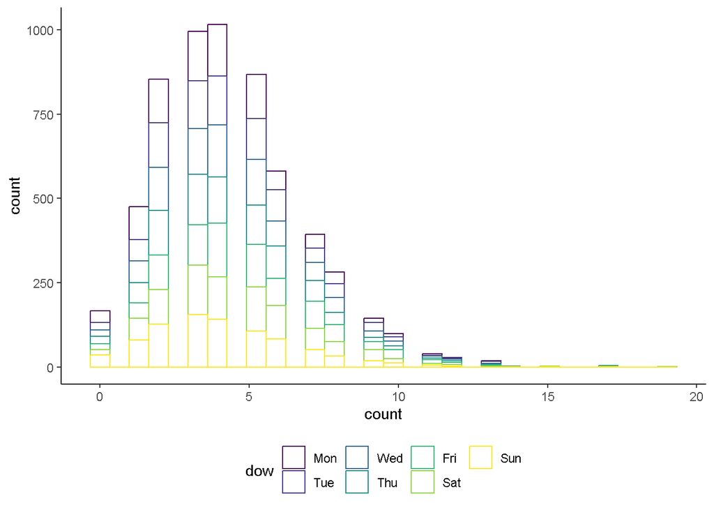

```r
ggplot(calls.day, aes(x= count, colour = dow)) +
  geom_histogram(fill = "white") +
  theme_classic() +
  theme(legend.position = "bottom")
```

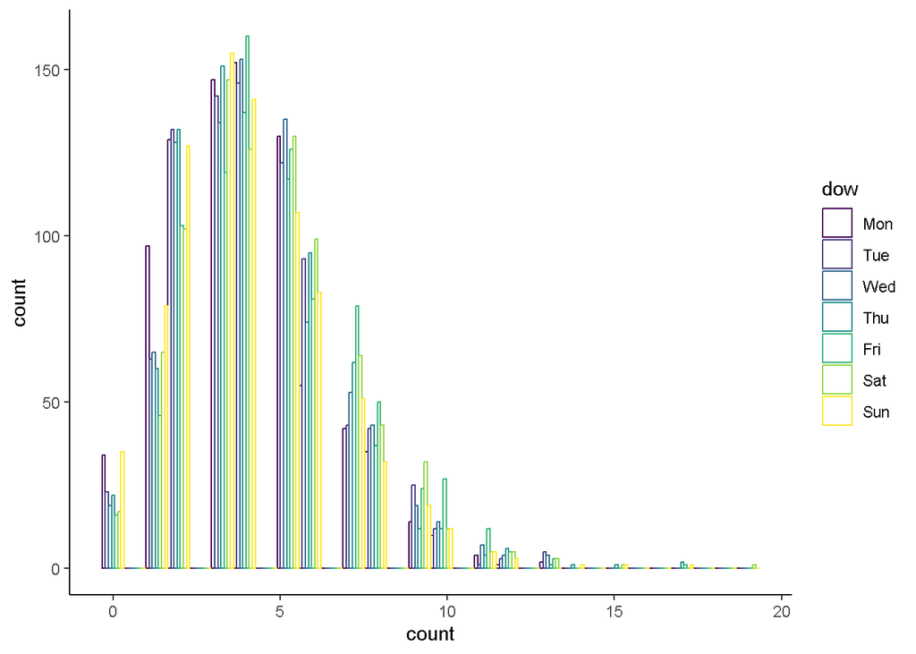

```r
ggplot(calls.day, aes(x= count, colour = dow)) +
  geom_histogram(fill = "white", position = "dodge") +
  theme_classic() +
  theme(legend.position = "right")
```

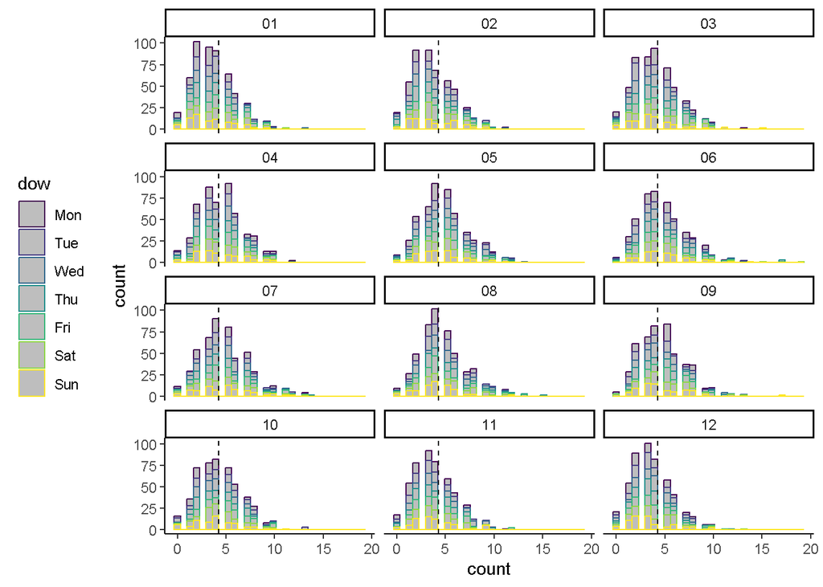

```r
ggplot(calls.day, aes(x= count, colour = dow)) +
  geom_histogram(fill = "grey") +
  geom_vline(data = calls.day, aes(xintercept = mean(count)), linetype = "dashed") +
  theme_classic() +
  theme(legend.position = "left") +
  facet_wrap(~ month.num, nrow = 4)
```

#STEP FIVE: TOPOLOGIES FOR DAY & HOUR/ DAY, HOUR, & YEAR/MONTH & YEAR ##For City of Fairfax Suspicious Calls

```r
# Step 5
calls.day.time <- calls %>%
  group_by(dow, hour) %>%
  summarise(count = n())
calls.day.time <- subset(calls.day.time, !is.na(calls.day.time$hour))
```

```r
#For day, hour, and year
calls.year.day.time <- calls %>%
  group_by(year, dow, hour) %>%
  summarise(count = n())
calls.year.day.time <- subset(calls.year.day.time, !is.na(calls.year.day.time$hour))
```

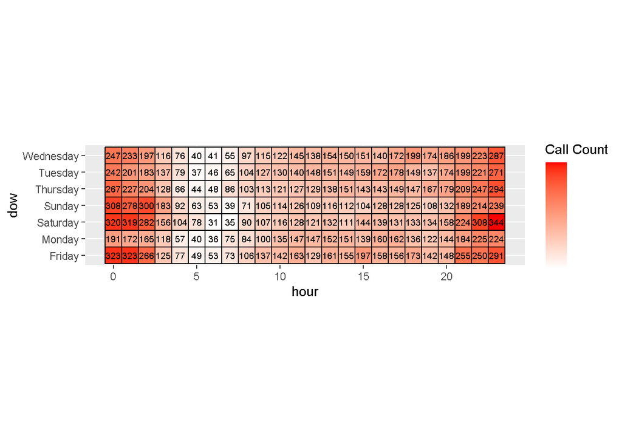

```r
# for day and hour
ggplot(calls.day.time, aes(hour, dow, fill = count)) +
  geom_tile(color = "black", lwd = .5, linetype = 1) +
  geom_text(aes(label = count), color = "black", size = 2.5) +
  scale_fill_gradient(low = "white", high = "red") +
  guides(fill = guide_colourbar(title = "Call Count", label = FALSE, ticks = FALSE)) +
  coord_fixed()
```

```r
#For day, hour, and year
calls.year.day.time <- calls %>%
  group_by(year, dow, hour) %>%
  summarise(count = n())
```

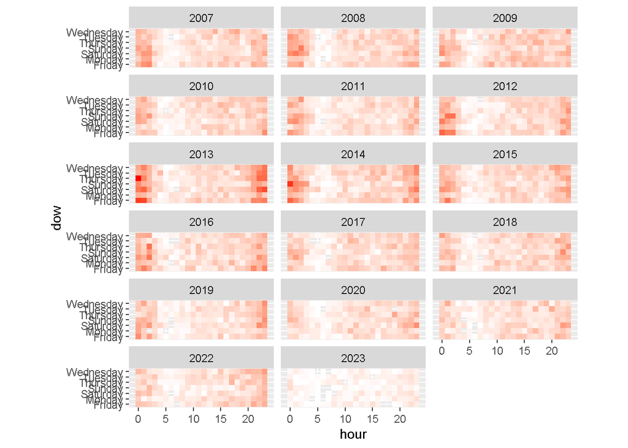

```r
calls.year.day.time <- subset(calls.year.day.time, !is.na(calls.year.day.time$hour))

ggplot(calls.year.day.time, aes(hour, dow, fill = count)) +
  geom_tile() +
  scale_fill_gradient(low = "white", high = "red") +
  theme(legend.position = "none") +
  coord_fixed() +
  facet_wrap(~ year, nrow = 6)
```

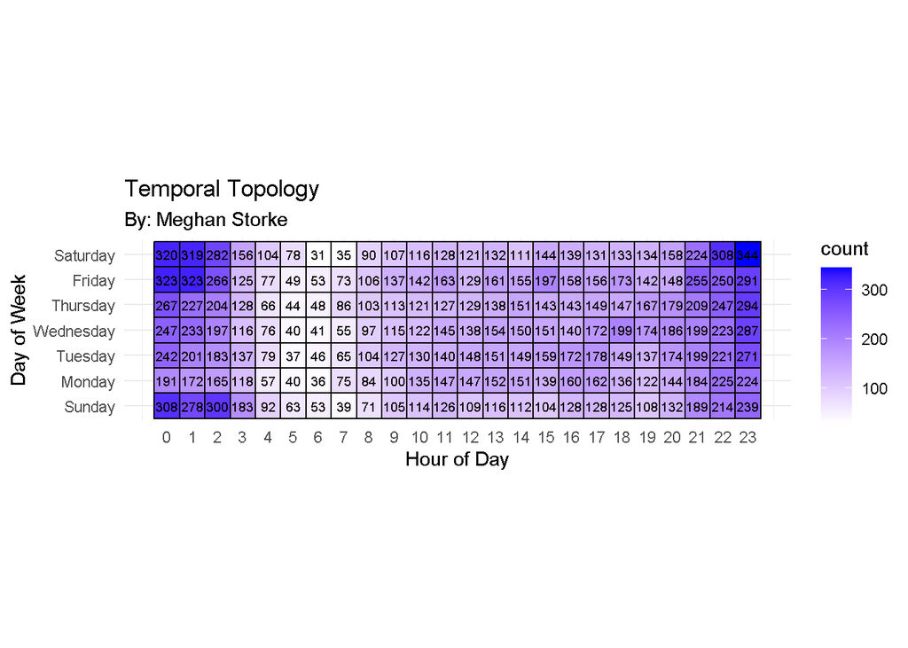

```r
graph <- ggplot(calls.day.time, aes(hour, dow, fill = count)) +
  geom_tile(color = "black", lwd = .5, linetype = 1) +
  geom_text(aes(label = count), color = "black", size = 2.5) +
  scale_fill_gradient(low = "white", high = "blue") +
  theme(legend.position = "none") +
  coord_fixed()

graph +
  labs(x = "Hour of Day", y = "Day of Week",
       title = "Temporal Topology",
       subtitle = "By: Meghan Storke") +
  scale_y_discrete(limits = c("Sunday", "Monday", "Tuesday", "Wednesday", "Thursday", "Friday", "Saturday")) +
  scale_x_continuous(breaks = c(0:23)) +
  theme_minimal()
```

```r
# month and year
calls.year.month <- calls %>%
  group_by(year, month) %>%
  summarise(count = n())
```

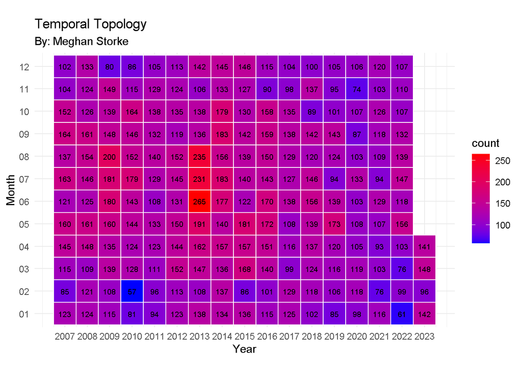

```r
calls.year.month <- subset(calls.year.month, !is.na(calls.year.month$month))

graph2 <- ggplot(calls.year.month, aes(year, month, fill = count)) +
  geom_tile(color = "white", lwd = .5, linetype = 1) +
  geom_text(aes(label = count), color = "black", size = 2.5) +
  scale_fill_gradient(low = "blue", high = "red") +
  theme(legend.position = "none") +
  coord_fixed()

graph2 +
  labs(x = "Year", y = "Month",
       title = "Temporal Topology",
       subtitle = "By: Meghan Storke") +
  scale_x_continuous(breaks = c(2007:2023)) +
  theme_minimal()
```

#ANALYSIS

#Month of year hotspots and coldspots, and what to expect during August 2023: The months of June (265), July (231), and August (235) yielded a lot of calls in 2013. Then August 2009 had 200 calls. Those were the only months that had upwards of 200 calls. For coldspots, February 2010 (57), November 2020 (74), February 2021 (76), January 2022 (61), and March 2022 (76) all had the lowest number of calls. If trends continue, August 2023 should see calls hover around the 120-155 mark. Notable exceptions for August were years 2020 (103) and 2021 (109), probably because of the pandemic.

#Hour of day hotspots, coldspots, trends, and patterns: Hotspot hourly patterns were strongest between 0 (midnight) and 2 a.m., and 22 thru 23 (10 and 11 p.m.) hours. These times of day when most people are asleep, so criminals think this is the best time to strike. The coldest spots hourly are between 5 and 7 a.m. This is the time period when most people are waking up, drinking coffee, getting ready for work, letting pets out, etc. People stirring makes it less likely to get away with crime.